# Exploratory Data ANalysis of 2016 Presidential Election Contributions in Illinois

Hala Jadallah

## Introduction:

In this report we perform an exploratory analysis of presidential elections contributions in Illinois, the state of my residence. For this purpose I downloaded three files:

1. 2016 Presidential elections contributions raw data from  
   ftp://ftp.fec.gov/FEC/Presidential_Map/2016/DATA_DICTIONARIES/CONTRIBUTOR_FORMAT.txt in January 2018

```
## 'data.frame':    250411 obs. of  19 variables:
##  $ contbr_nm        : Factor w/ 52686 levels "'CALLAHAN, CHRIS",..: 15057 38033 27566 36136 28537 22091 22091 11408 3585 18652 ...
##  $ cmte_id          : Factor w/ 24 levels "C00458844","C00500587",..: 6 15 7 15 7 7 7 6 6 6 ...
##  $ cand_id          : Factor w/ 24 levels "P00003392","P20002671",..: 1 23 12 23 12 12 12 1 1 1 ...
##  $ cand_nm          : Factor w/ 24 levels "Bush, Jeb","Carson, Benjamin S.",..: 4 22 19 22 19 19 19 4 4 4 ...
##  $ X                : logi  NA NA NA NA NA NA ...
##  $ contbr_city      : Factor w/ 1521 levels "0LMSTED","25 F CHICAGO",..: 715 617 243 243 1081 243 243 201 1489 1007 ...
##  $ contbr_st        : Factor w/ 1 level "IL": 1 1 1 1 1 1 1 1 1 1 ...
##  $ contbr_zip       : int  601564641 60192 606223057 60622 615542542 606576225 606576225 622311258 600911971 619430433 ...
##  $ contbr_employer  : Factor w/ 17536 levels "","-","--","(NONE)",..: 13786 13839 17462 7625 6922 11229 11229 7625 10075 10695 ...
##  $ contbr_occupation: Factor w/ 8363 levels "","-","--"," CERTIFIED REGISTERED NURSE ANESTHETIS",..: 6565 1220 8239 3643 6129 4888 4888 3643 6536 6338 ...
##  $ contb_receipt_amt: num  33.5 400 50 601.6 15 ...
##  $ contb_receipt_dt : Factor w/ 682 levels "1-Apr-15","1-Apr-16",..: 176 235 609 390 587 609 609 421 44 2 ...
##  $ receipt_desc     : Factor w/ 32 levels "","* EARMARKED CONTRIBUTION: SEE BELOW REATTRIBUTION/REFUND PENDING",..: 1 1 1 1 1 1 1 1 1 1 ...
##  $ memo_cd          : Factor w/ 2 levels "","X": 2 2 1 2 1 1 1 2 2 2 ...
##  $ memo_text        : Factor w/ 126 levels "","$0.04 REFUNDED ON 10/25/2016",..: 23 1 18 1 18 18 18 23 23 23 ...
##  $ form_tp          : Factor w/ 3 levels "SA17A","SA18",..: 2 2 1 2 1 1 1 2 2 2 ...
##  $ file_num         : int  1091718 1146165 1077404 1146165 1077404 1077404 1077404 1091718 1091718 1091718 ...
##  $ tran_id          : Factor w/ 249967 levels "A0026BD64F7D64A08896",..: 85172 172660 201960 172648 201573 201985 202122 85468 85069 84821 ...
##  $ election_tp      : Factor w/ 5 levels "","G2016","O2016",..: 4 2 4 2 4 4 4 4 4 4 ...
```

Important variables in this data set are: candidate names, contribution amount and date, contributor city, and election type.

I choose to ignore zip codes in this analysis and use cities to consider the spatial distribution of contributors.

Therefore I download two other Illinois data sources.

2. A list of IL cities and their population obtained from the Wikipedia page https://en.wikipedia.org/wiki/List_of_municipalities_in_Illinois
3. location coordinated of Illinois cities obtained from https://www.mapsofworld.com/usa/states/illinois/lat-long.html

Now we load the data and join the last two files based on location name and type: city, village, town or unincorporated.

```
## The number of unincorporated populated locations is:  69
```

We merge city population type longitude and latitude for most of Illinois cities.

```
##         city    type population    county latitude longitude
## 1   Abingdon    City      3,319      Knox    40.80    -90.40
## 2 Addieville Village        252      Knox    38.39    -89.49
## 3    Addison Village     36,942    DuPage    41.93    -88.01
## 4    Adeline Village         85      Ogle    42.14    -89.49
## 5     Albany Village        891 Whiteside    41.79    -90.22
## 6     Albers Village       1190   Clinton    38.55    -89.61
```

Here is a view of the cities on Illinois map.

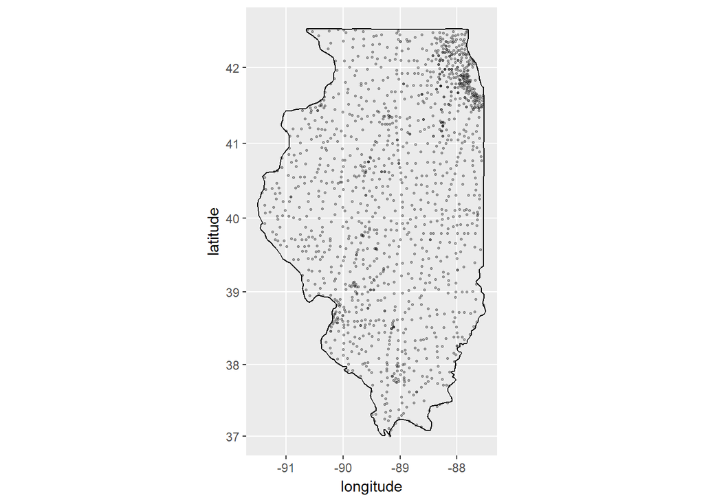

Many cities in the contributions data set are misspelled, so I had to capture them and correct them as much as possible. In doing so, I realized that the data of contributions has three types of cities or places. First, places with municipalities, these are categorized as cities, villages and towns by the state. Second, there are cities that are considered unincorporated populated areas. Presumably, they have low count of people, and there is no solid population count that I could find tabulated. Third, there are cities that do not lie in Illinois. There are either in other states or they are in foreign countries.

# Exploration of presidential contributions

First we list candidates with the number of contributions.

The count of contributions here includes refunds and some non-unique contributors.

```r
print(count(IL.presContr,cand_nm), n=24, width=Inf)
```

```
## # A tibble: 24 x 2
##    cand_nm                        n
##    <fct>                      <int>
##  1 Bush, Jeb                    631
##  2 Carson, Benjamin S.         5983
##  3 Christie, Christopher J.     127
##  4 Clinton, Hillary Rodham   122634
##  5 Cruz, Rafael Edward 'Ted'  13366
##  6 Fiorina, Carly               678
##  7 Graham, Lindsey O.            94
##  8 Huckabee, Mike               161
##  9 Jindal, Bobby                  3
## 10 Johnson, Gary                448
## 11 Kasich, John R.             1045
## 12 Lessig, Lawrence              65
## 13 McMullin, Evan                34
## 14 O'Malley, Martin Joseph      164
## 15 Pataki, George E.              6
## 16 Paul, Rand                  1171
## 17 Perry, James R. (Rick)         2
## 18 Rubio, Marco                2987
## 19 Sanders, Bernard           76502
## 20 Santorum, Richard J.          27
## 21 Stein, Jill                  406
## 22 Trump, Donald J.           23367
## 23 Walker, Scott                500
## 24 Webb, James Henry Jr.         10
```

Observe that number of contributions to the 24 candidates are at different order of magnitude.

Its easier to refer to candidates by their last names. Therefore I create a variable for each candidate’s last name, a variable for the candidate’s party, and another for candidate’s gender.

I also cleaned the date format. For example 11-Jan-16 is turned into 11-01-2016.

## Univariate Plots

Here we will explore the variable that I consider important in understanding contributions to 2016 presidential candidates.

The first plot we look at is a bar plot of presidential candidates.

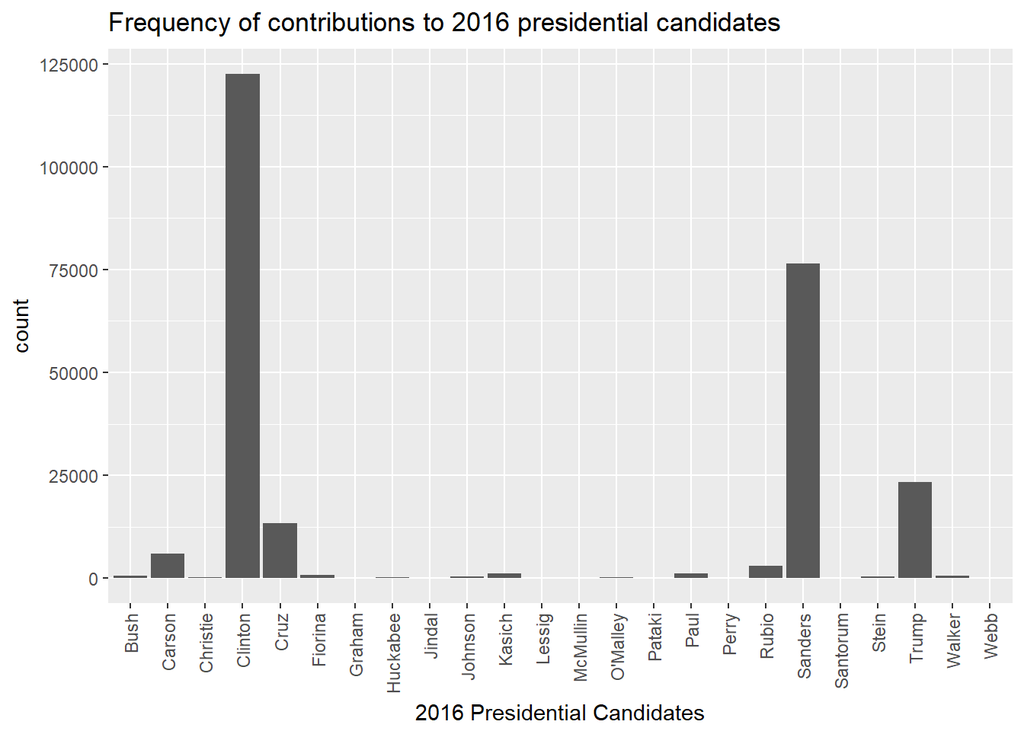

We see that the number of contribution in decreasing order went to :Clinton, Sanders, Trump, Cruz, Carson, and Robio. we see that the number of contributions to each of these candidates was a different order of magnitude. Clinton and Sanders seem to have most of the contributions around 80% of all contributions.

Next we look at the election type variable. It has four levels: P2016, G2016, O2016, P2020, and one with no title, either the contribution is unspecified, or there was an error.

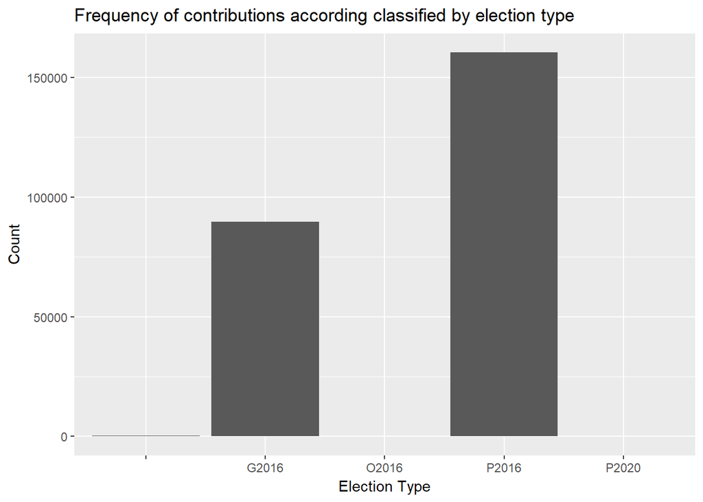

We Observe as we expect that most contributions go either for the primary P2016, or the general elections G2016.

Next we look at frequency of contributions at the lace of origin. Places are classified as cities, towns and villages. Unclassified places are either unincorporated, that is populated places with no municipality or that is a place that lies outside the state.

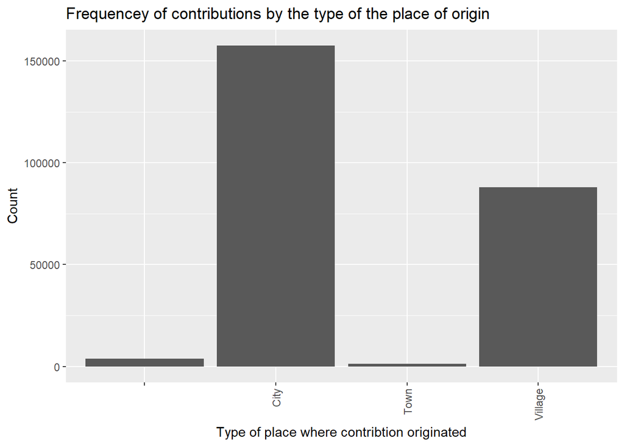

We see that most of the contributions came from cities , then villages. Much less from towns or places other than the above.

Here is the exact count in each type

```r
summary(contrib$type)
```

```
##            City    Town Village
##    3731  157507    1240   87933
```

Here is a summery of the number of cities , towns and villages in Illinois

```r
summary(IL_city_sl$type)
```

```
##            City    Town Village
##       0     327      19    1036
```

This explains why so many contributions came from cities and villages we need to look at the population in these places. Here is a summary of the population

```r
with(data = IL_city_sl, by(as.numeric(population), type, summary))
```

```
## type:
## NULL
## --------------------------------------------------------
## type: City
##    Min. 1st Qu.  Median    Mean 3rd Qu.    Max.
##     236    2098    5309   24724   16731 2695598
## --------------------------------------------------------
## type: Town
##    Min. 1st Qu.  Median    Mean 3rd Qu.    Max.
##      35     128     373    7816    1173   83891
## --------------------------------------------------------
## type: Village
##    Min. 1st Qu.  Median    Mean 3rd Qu.    Max.
##      13     313     717    4824    3200   75101
```

Here is the summary of the total population in Illinois. Notice that 75% of the places in the state are populated by at most 6200.

```
##      Min.   1st Qu.    Median      Mean   3rd Qu.      Max.
##      13.0     408.2    1185.0    9573.8    6119.5 2695598.0
```

Now we switch to explore population of places where contributions originated.

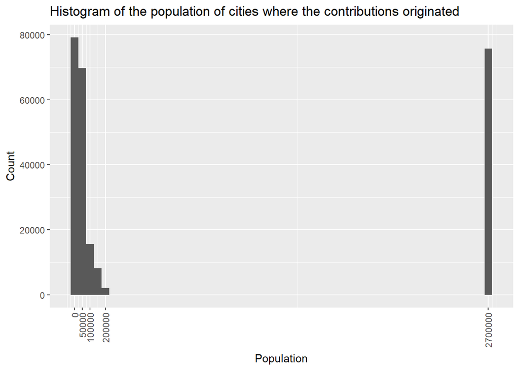

Chicago the most populous city in the state naturally stands alone among the most contributed place. Places with population less than 50,000 contributed slightly more, while places with population between 50,000 and 100,000 contributed slightly less than Chicago.

To put things in perspective lets look at the histogram of the population of the cities in IL. Notice that the histogram below shows the frequency of locatios(cities, villages and towns) based on their population.

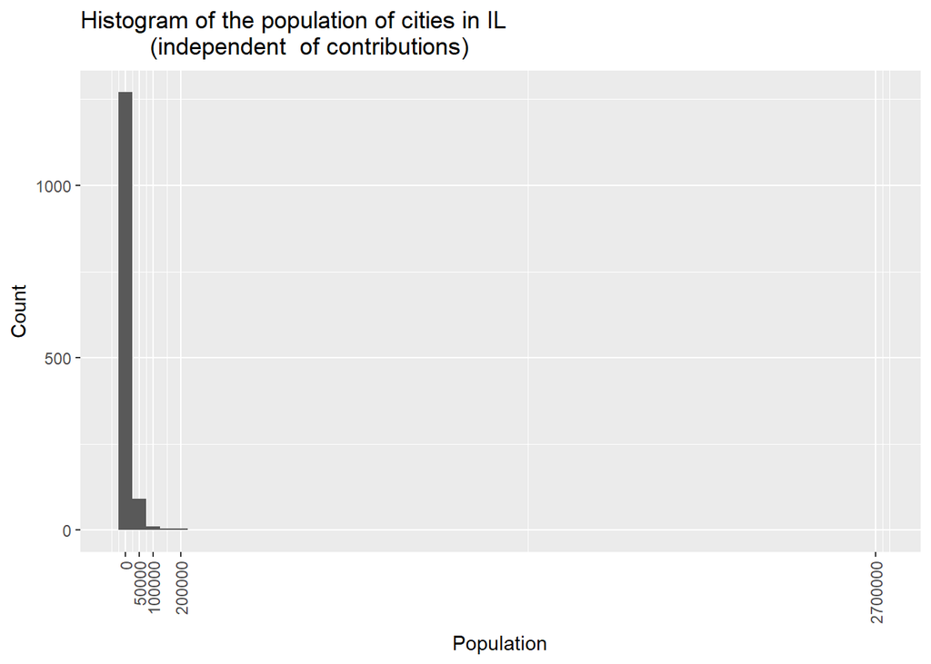

As the summary of populations showed, places in the state are mainly populated by less than 50000.

Below is a zoomed-in view of population histogram excluding Chicago, and with smaller binwidth of only 5000. The binwidth in the above histogram is 50000.

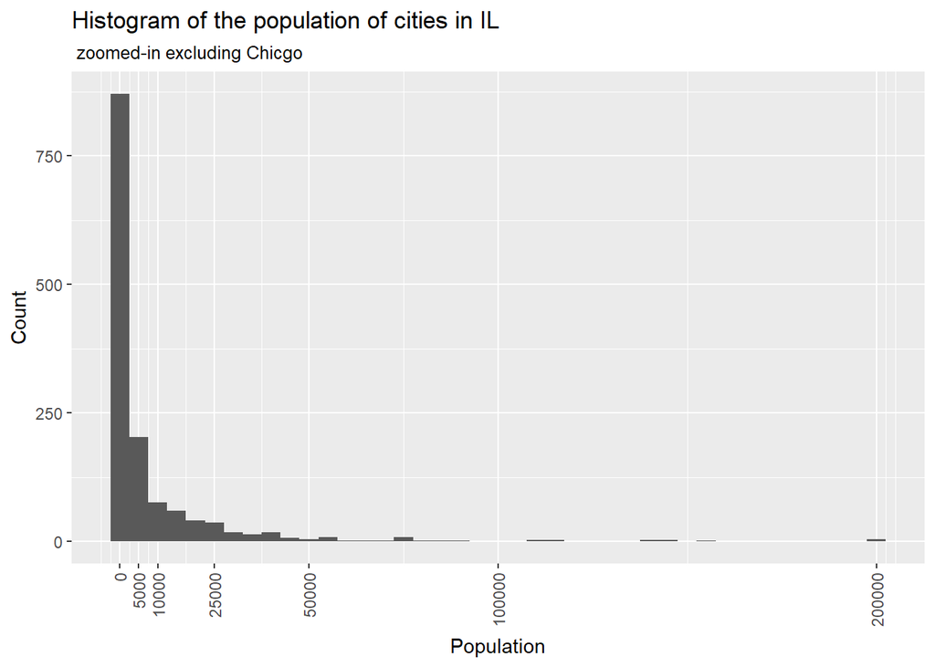

The histogram above show that most places have low population, less than 5000.

Lets look at the population histogram on a logarithmic scale so that we appreciate the number of places with very low population sizes.

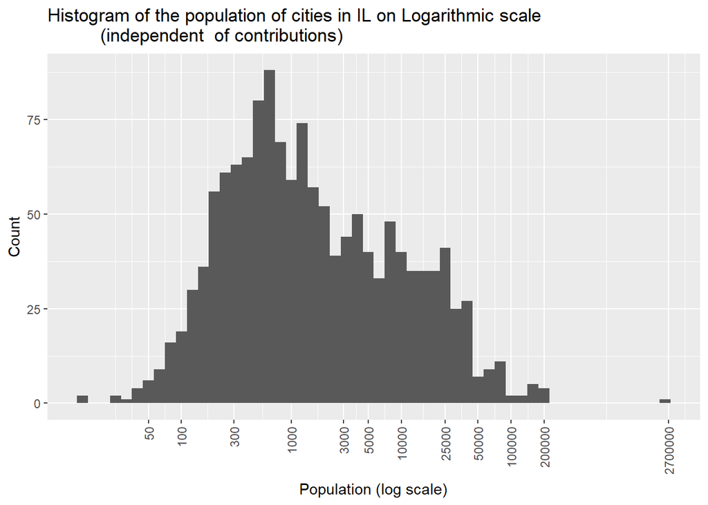

The plot above show the density of places with population less than 3000. Recall the median of the population distribution among cities is 1185 and the third quartile is 6200.

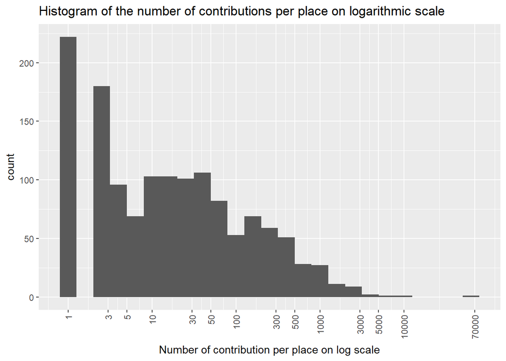

We observe from the plot above that most places made less than 50 contributions. However this not surprising since half of the places have population less than 1185.

Below we look at the ratio of the number of contributions to the population of the place where the contributions originated.

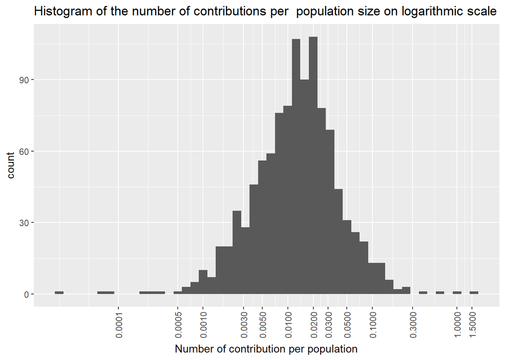

The plot of the number of contribution to population ratio shows that for most places less than 2% of its population made a contribution. However, there are places where the ratio is 1.5; which implies that some groups have contributed more than once where the population size is small.

Now we look at frequency of dates when contributions where made.

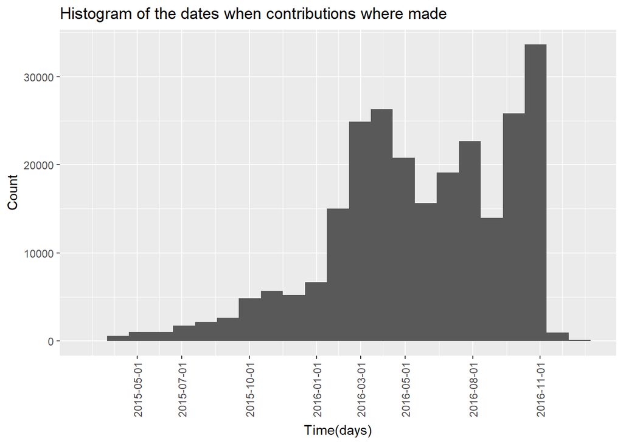

Notice that at the beginning, contributions where minimal and then gradually increased as time progressed. We observe some peak in March 2016, July 2016 and October 2016. These are could be in response to campaign drives asking for donations/contributions.

Next, we plot a histogram of contributed amounts.

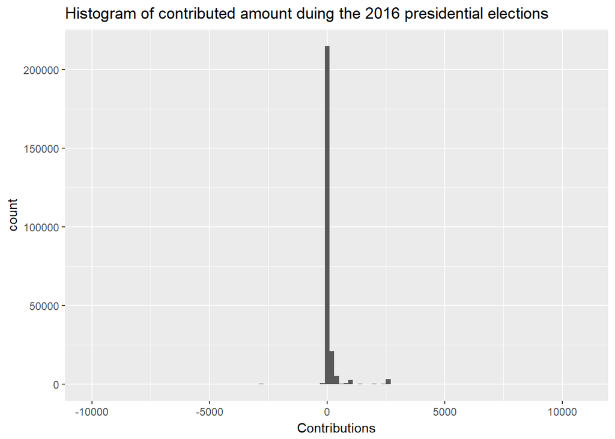

We notice first that most contributions are less than 200, the binwidth of this histogram.

We observe from the histogram that there are negative values, which are refunds. I did not know that people ask for a refund after their donation. This was a surprise. we make a plot of each separately. I use the log scale for the counts since small contributions are plenty compared to much fewer much larger contributions.

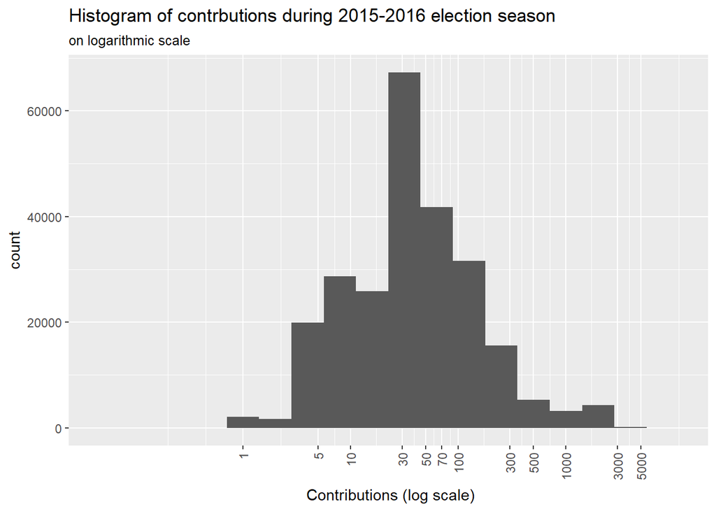

We observe from the above that most contributions are less than $70. I estimate the first quartile to be $15. While contributions of $3000 or more are rare.

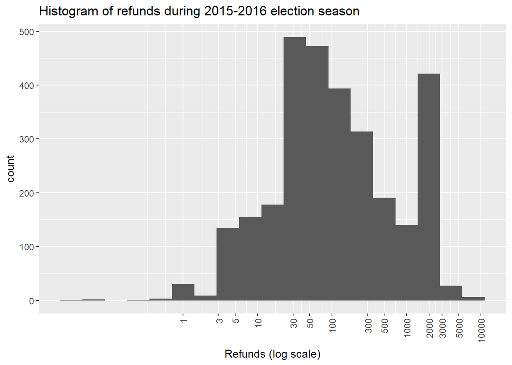

We see from the above graph that the refunded amounts had a wide range, mostly small refunds less than $100 and the largest refund is $10000. We also observe a second peak of more than 400 refunds of size $2000.

## Bivariate plots

Below is a table that gives the number of contributions classified by purpose as for primary elections,or general elections. Not quite sure what O2016 refers to. The only candidate with counts in this column is Jill Stein. The dates of these donation are from 23-Nov-2016 to 28-Nov-2016. Stein has counts for primary and general elections as well. There is also a column for 2020 presidential election contributions which has one contribution to Lindsay Graham

Moreover, some candidates who had pulled out of the race, show counts under G2016. Its very likely, that these refer to refunds.

```
##
##                                   G2016 O2016 P2016 P2020
##   Bush, Jeb                     0    19     0   612     0
##   Carson, Benjamin S.          11    60     0  5912     0
##   Christie, Christopher J.      0     0     0   127     0
##   Clinton, Hillary Rodham       0 77028     0 45606     0
##   Cruz, Rafael Edward 'Ted'    19   202     0 13145     0
##   Fiorina, Carly                0     0     0   678     0
##   Graham, Lindsey O.            1     7     0    85     1
##   Huckabee, Mike                0     0     0   161     0
##   Jindal, Bobby                 0     0     0     3     0
##   Johnson, Gary                 0   428     0    20     0
##   Kasich, John R.               0    27     0  1018     0
##   Lessig, Lawrence              2     1     0    62     0
##   McMullin, Evan               18    16     0     0     0
##   O'Malley, Martin Joseph       4     0     0   160     0
##   Pataki, George E.             0     0     0     6     0
##   Paul, Rand                    0    30     0  1141     0
##   Perry, James R. (Rick)        0     0     0     2     0
##   Rubio, Marco                  0   160     0  2827     0
##   Sanders, Bernard              0     0     0 76502     0
##   Santorum, Richard J.          0     0     0    27     0
##   Stein, Jill                   3   195    70   138     0
##   Trump, Donald J.            302 11384     0 11681     0
##   Walker, Scott                 0    36     0   464     0
##   Webb, James Henry Jr.         0     0     0    10     0
```

I am curious about the O2016 category that only Stein falls into. Here is a summary of the 70 contributions to Jill Stein in O2016 category

```
##    Min. 1st Qu.  Median    Mean 3rd Qu.    Max.
##   250.0   300.0   500.0   622.6   500.0  2700.0
```

From the above we conclude that “O” in O2016 is most likely to be “other”, and referring to contributions following the elections.

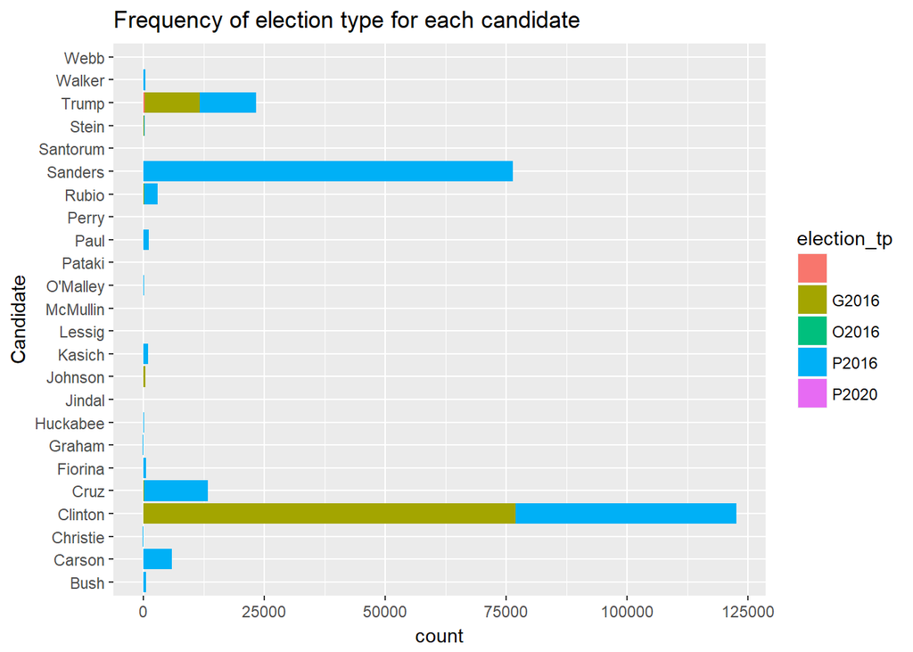

We repeat the same bar plot but with election type bars next to each other.

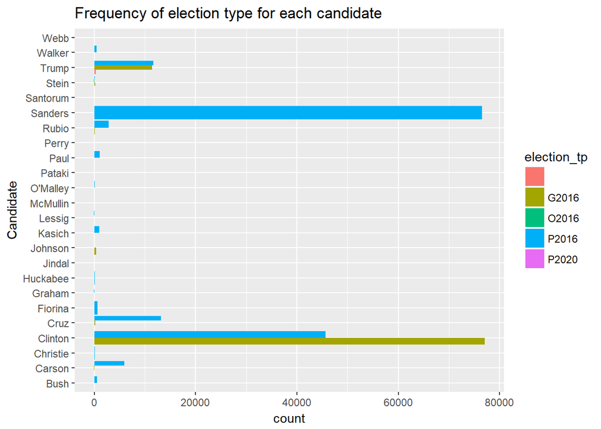

We observe that the front runners among the democrats are Clinton and Sanders, with Sanders receiving more contributions before the primaries. While among the republicans, the front runners are Trump and Cruz with almost equal number of supporters.

Below is the same plot but restricted to include no refunds. The noticeable change is with Trumps G2016 contributions go down slightly.

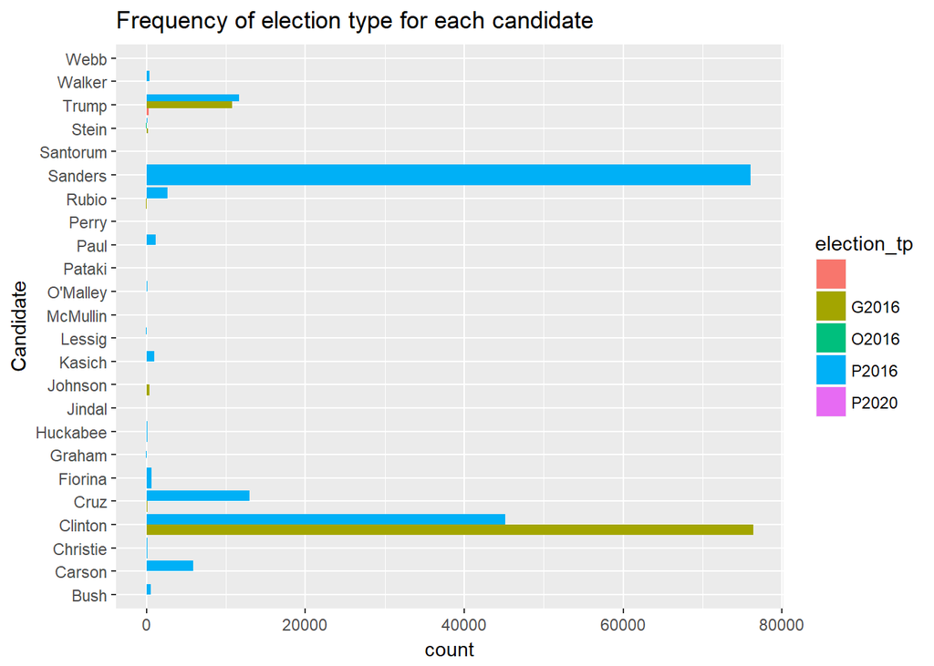

Below is a summary of sum, mean, median, 25th percentile, 75th percentile, 90th percentile and max contributions for each party. Notice the gap between the 90th percentile and the maximum contributed amount.

```
## # A tibble: 5 x 11
##   cand_party      Total  Mean Quart_1 Median Quart_3 Perct_90   Max
##   <chr>           <dbl> <dbl>   <dbl>  <dbl>   <dbl>    <dbl> <dbl>
## 1 Democrat    19603816.  98.3      11     25      50      128  5400
## 2 Green         103449. 255.       29    100     250      500  2700
## 3 Independent     6263. 184.       25     75     250      500  1000
## 4 Liberterian   112087. 250.       50    100     250      500  5400
## 5 Republican   8502377  170.       25     50     100      360 10800
##       var   std      n
##     <dbl> <dbl>  <int>
## 1 114718.  339. 199375
## 2 181550.  426.    406
## 3  54793.  234.     34
## 4 336438.  580.    448
## 5 365883.  605.  50148
```

A summary of mean, median and sum and number of contributions for each candidate towards any category, primaries p2016, general election G2016, P2020, O2016, or anything else.

```
## # A tibble: 24 x 5
##    cand_nm                       total amt_mean amt_median      n
##    <fct>                         <dbl>    <dbl>      <dbl>  <int>
##  1 Bush, Jeb                   640064    1014.       300      631
##  2 Carson, Benjamin S.         638878.    107.        50     5983
##  3 Christie, Christopher J.    162273    1278.      1000      127
##  4 Clinton, Hillary Rodham   16152027.    132.        25   122634
##  5 Cruz, Rafael Edward 'Ted'  1241113.     92.9       50    13366
##  6 Fiorina, Carly              146238.    216.       100      678
##  7 Graham, Lindsey O.           86510     920.       500       94
##  8 Huckabee, Mike               18500.    115.        50      161
##  9 Jindal, Bobby                 5500    1833.      2700        3
## 10 Johnson, Gary               112087.    250.       100      448
## 11 Kasich, John R.             539898.    517.       250     1045
## 12 Lessig, Lawrence             21394.    329.       200       65
## 13 McMullin, Evan                6263.    184.        75       34
## 14 O'Malley, Martin Joseph     127137     775.       500      164
## 15 Pataki, George E.             4200     700        250        6
## 16 Paul, Rand                  196795.    168.        50     1171
## 17 Perry, James R. (Rick)        1000     500        500        2
## 18 Rubio, Marco                964159.    323.       100     2987
## 19 Sanders, Bernard           3295108.     43.1       27    76502
## 20 Santorum, Richard J.         11322.    419.       250       27
## 21 Stein, Jill                 103449.    255.       100      406
## 22 Trump, Donald J.           3490011.    149.        55.1  23367
## 23 Walker, Scott               355916     712.       250      500
## 24 Webb, James Henry Jr.         8150     815        500       10
```

Lets now have a look at a summary of contributions that candidates got towards the primary election 2016 only.

```
## # A tibble: 23 x 5
##    cand_last_nm    total   mean median     n
##    <chr>           <dbl>  <dbl>  <dbl> <int>
##  1 Bush          639090  1044.     300   612
##  2 Carson        658070.  111.      50  5912
##  3 Christie      162273  1278.    1000   127
##  4 Clinton      8202697.  180.      25 45606
##  5 Cruz         1269172.   96.6     50 13145
##  6 Fiorina       146238.  216.     100   678
##  7 Graham         82410   970.     500    85
##  8 Huckabee       18500.  115.      50   161
##  9 Jindal          5500  1833.    2700     3
## 10 Johnson        14000.  700.     500    20
## 11 Kasich        499398.  491.     250  1018
## 12 Lessig         18448.  298.     225    62
## 13 O'Malley      127077   794.     500   160
## 14 Pataki          4200   700      250     6
## 15 Paul          187281.  164.      50  1141
## 16 Perry           1000   500      500     2
## 17 Rubio         997139.  353.     100  2827
## 18 Sanders      3295108.   43.1     27 76502
## 19 Santorum       11322.  419.     250    27
## 20 Stein          33953   246.     250   138
## 21 Trump        1085737.   92.9     40 11681
## 22 Walker        353716   762.     250   464
## 23 Webb            8150   815      500    10
```

Comparing the above two tables in terms of the amount they received over the full election season and the amount they got towards the primaries, we see for those candidates who continued to the general elections had their amount at least double.

Lets look at a distribution of the contributed amount for each party.

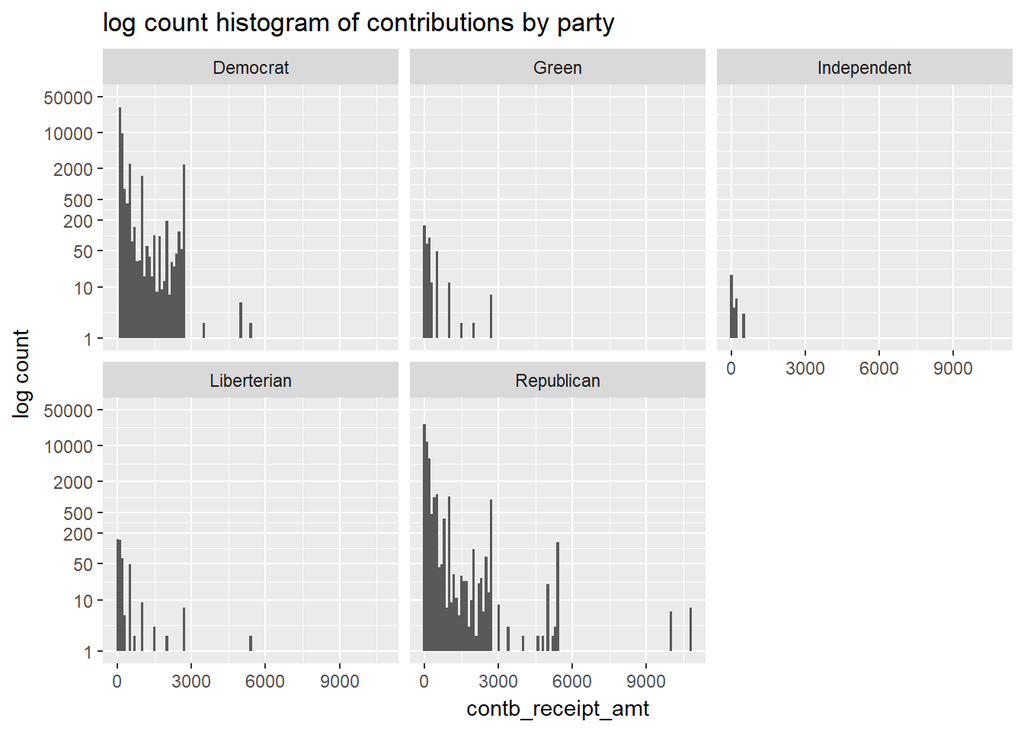

We observe from this histogram that Democrats and Republicans are comparable with the Democrats receiving smaller amounts while Republicans getting more large amounts.

We also see that the Green and Libertarian parties are comparable.

Now we look at visual summaries of contribution for each candidate using box-plots. We look at Democratic candidates and Republican candidates separately.

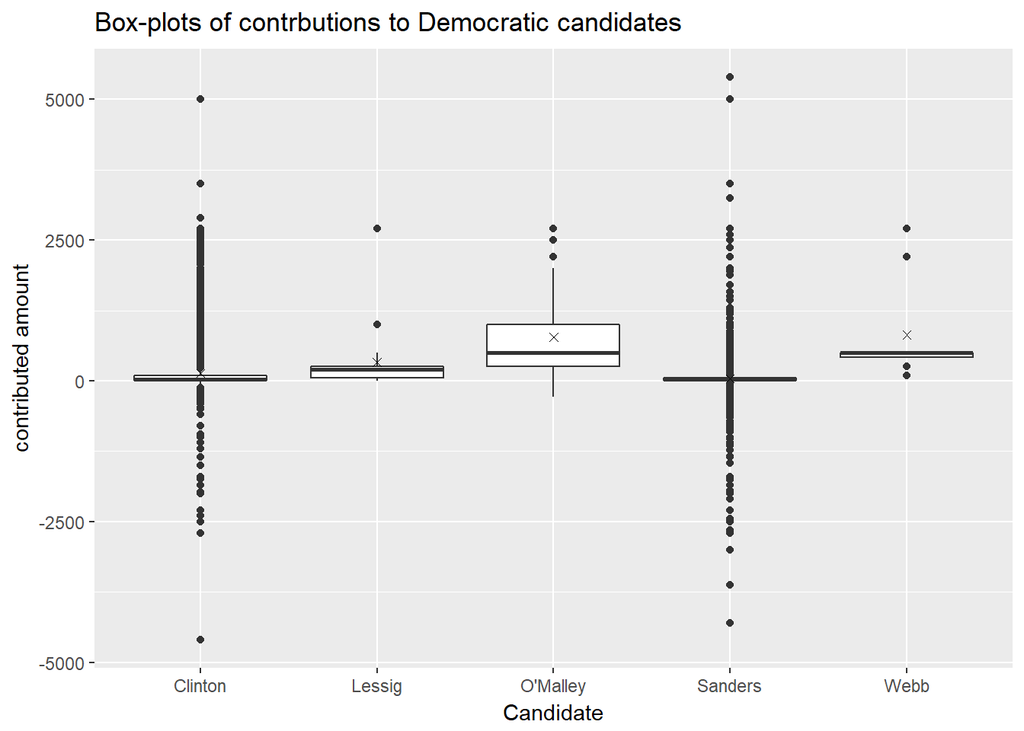

The box plot shows that enthusiasm towards Sanders is as strong as that for Clinton. Mostly they received small contributions.

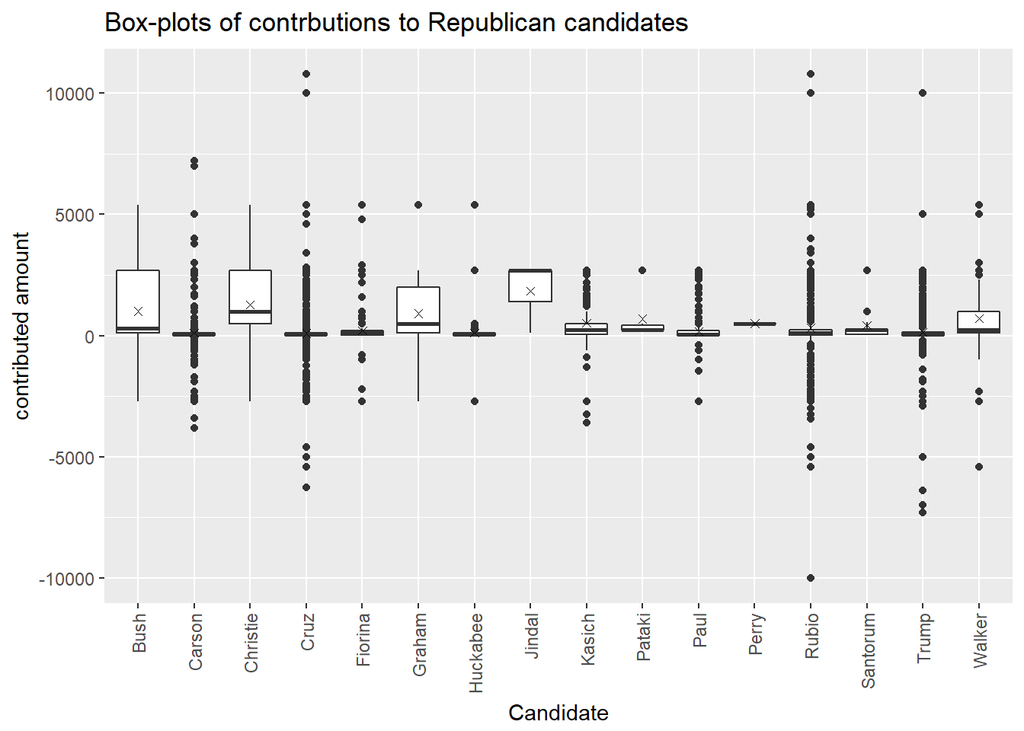

Among republicans, we see that Carson, Cruz, Rubio and Trump receiving mainly small contributions in addition with the upper 25% of contributions was very spread out reaching as high as 10000 dollars.

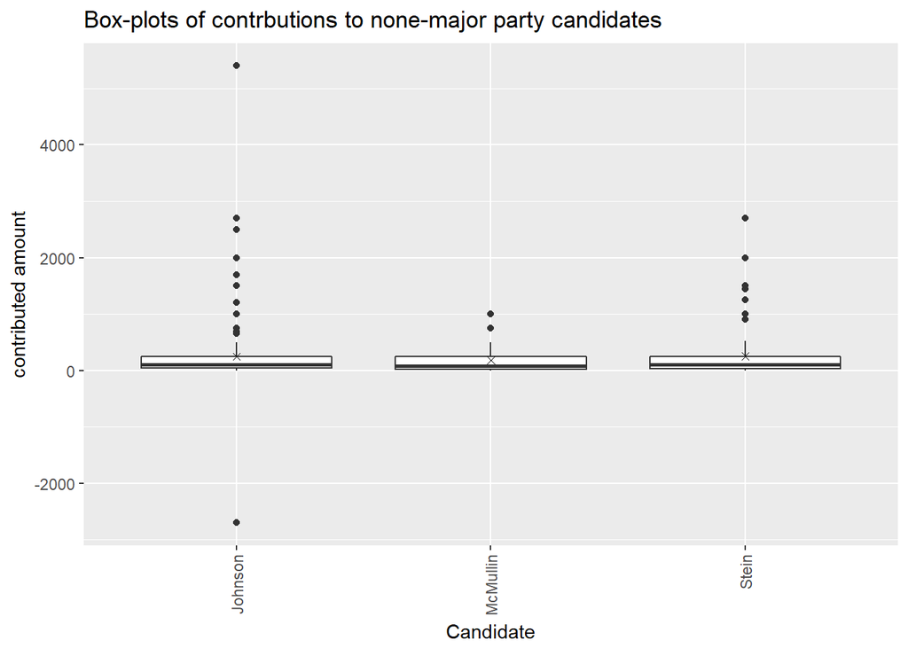

We see that the Green party and Libertarian party have comparable contributions

A summary of contributions for each candidate

```
## cand_nm: Bush, Jeb
##    Min. 1st Qu.  Median    Mean 3rd Qu.    Max.
##   -2700     100     300    1014    2700    5400
## --------------------------------------------------------
## cand_nm: Carson, Benjamin S.
##    Min. 1st Qu.  Median    Mean 3rd Qu.    Max.
## -3800.0    25.0    50.0   106.8   100.0  7200.0
## --------------------------------------------------------
## cand_nm: Christie, Christopher J.
##    Min. 1st Qu.  Median    Mean 3rd Qu.    Max.
##   -2700     500    1000    1278    2700    5400
## --------------------------------------------------------
## cand_nm: Clinton, Hillary Rodham
##    Min. 1st Qu.  Median    Mean 3rd Qu.    Max.
## -4600.0    12.0    25.0   131.7   100.0  5000.0
## --------------------------------------------------------
## cand_nm: Cruz, Rafael Edward 'Ted'
##     Min.  1st Qu.   Median     Mean  3rd Qu.     Max.
## -6250.00    25.00    50.00    92.86   100.00 10800.00
## --------------------------------------------------------
## cand_nm: Fiorina, Carly
##    Min. 1st Qu.  Median    Mean 3rd Qu.    Max.
## -2700.0    25.0   100.0   215.7   200.0  5400.0
## --------------------------------------------------------
## cand_nm: Graham, Lindsey O.
##    Min. 1st Qu.  Median    Mean 3rd Qu.    Max.
## -2700.0   100.0   500.0   920.3  2000.0  5400.0
## --------------------------------------------------------
## cand_nm: Huckabee, Mike
##    Min. 1st Qu.  Median    Mean 3rd Qu.    Max.
## -2700.0    25.0    50.0   114.9   100.0  5400.0
## --------------------------------------------------------
## cand_nm: Jindal, Bobby
##    Min. 1st Qu.  Median    Mean 3rd Qu.    Max.
##     100    1400    2700    1833    2700    2700
## --------------------------------------------------------
## cand_nm: Johnson, Gary
##    Min. 1st Qu.  Median    Mean 3rd Qu.    Max.
## -2700.0    50.0   100.0   250.2   250.0  5400.0
## --------------------------------------------------------
```

[output cut: 40 more lines]

```
## cand_nm: Stein, Jill
##    Min. 1st Qu.  Median    Mean 3rd Qu.    Max.
##     1.0    29.0   100.0   254.8   250.0  2700.0
## --------------------------------------------------------
## cand_nm: Trump, Donald J.
##     Min.  1st Qu.   Median     Mean  3rd Qu.     Max.
## -7300.00    28.00    55.13   149.36   160.00 10000.00
## --------------------------------------------------------
## cand_nm: Walker, Scott
##    Min. 1st Qu.  Median    Mean 3rd Qu.    Max.
## -5400.0   100.0   250.0   711.8  1000.0  5400.0
## --------------------------------------------------------
## cand_nm: Webb, James Henry Jr.
##    Min. 1st Qu.  Median    Mean 3rd Qu.    Max.
##     100     425     500     815     500    2700
```

Next I would like to see how many contributed in different contribution amounts for the front runners in the major parties.

```
## # A tibble: 11 x 6
## # Groups:   cand_last_nm [1]
##    cand_last_nm amt.bucket      amt_mean amt_median     n percent
##    <chr>        <fct>              <dbl>      <dbl> <int>   <dbl>
##  1 Clinton      (-5e+03,-1e+03]  -2077.      -2500     69  0.0563
##  2 Clinton      (-1e+03,-500]     -601.       -500     24  0.0196
##  3 Clinton      (-500,-100]       -168.       -148.   326  0.266
##  4 Clinton      (-100,-50]         -59.7       -50    191  0.156
##  5 Clinton      (-50,0]            -16.7       -15    537  0.438
##  6 Clinton      (0,50]              23.0        25  84659 69.0
##  7 Clinton      (50,100]            91.5       100  18970 15.5
##  8 Clinton      (100,200]          165.        156.  5488  4.48
##  9 Clinton      (200,500]          318.        250   7693  6.27
## 10 Clinton      (500,2e+03]       1128.       1000   2049  1.67
## 11 Clinton      (2e+03,5e+03]     2678.       2700   2628  2.14
```

```
## # A tibble: 12 x 6
## # Groups:   cand_last_nm [1]
##    cand_last_nm amt.bucket      amt_mean amt_median     n  percent
##    <chr>        <fct>              <dbl>      <dbl> <int>    <dbl>
##  1 Sanders      (-5e+03,-1e+03]  -1739.      -1408.    40  0.0523
##  2 Sanders      (-1e+03,-500]     -566.       -500     73  0.0954
##  3 Sanders      (-500,-100]       -202.       -173.   204  0.267
##  4 Sanders      (-100,-50]         -60.0       -50     74  0.0967
##  5 Sanders      (-50,0]            -21.8       -25     96  0.125
##  6 Sanders      (0,50]              23.2        25  64346 84.1
##  7 Sanders      (50,100]            94.0       100   8212 10.7
##  8 Sanders      (100,200]          156.        150   1065  1.39
##  9 Sanders      (200,500]          320.        250   2123  2.78
## 10 Sanders      (500,2e+03]       1038.       1000    235  0.307
## 11 Sanders      (2e+03,5e+03]     2807.       2700     32  0.0418
## 12 Sanders      (5e+03,1.1e+04]   5400        5400      2  0.00261
```

```
## # A tibble: 13 x 6
## # Groups:   cand_last_nm [1]
##    cand_last_nm amt.bucket      amt_mean amt_median     n percent
##    <chr>        <fct>              <dbl>      <dbl> <int>   <dbl>
##  1 Cruz         (-1e+04,-5e+03]  -5456.      -5400      8  0.0599
##  2 Cruz         (-5e+03,-1e+03]  -2465.      -2700    112  0.838
##  3 Cruz         (-1e+03,-500]     -607.       -500     40  0.299
##  4 Cruz         (-500,-100]       -206.       -162.    64  0.479
##  5 Cruz         (-100,-50]         -56         -50     20  0.150
##  6 Cruz         (-50,0]            -24.5       -25     36  0.269
##  7 Cruz         (0,50]              31.2        25   8907 66.6
##  8 Cruz         (50,100]            95.6       100   2539 19.0
##  9 Cruz         (100,200]          164.        150    519  3.88
## 10 Cruz         (200,500]          309.        250    827  6.19
## 11 Cruz         (500,2e+03]       1074.       1000    155  1.16
## 12 Cruz         (2e+03,5e+03]     2904.       2700     90  0.673
## 13 Cruz         (5e+03,1.1e+04]   6343.       5400     49  0.367
```

```
## # A tibble: 13 x 6
## # Groups:   cand_last_nm [1]
##    cand_last_nm amt.bucket      amt_mean amt_median     n  percent
##    <chr>        <fct>              <dbl>      <dbl> <int>    <dbl>
##  1 Trump        (-1e+04,-5e+03]  -6425.      -6700.     4  0.0171
##  2 Trump        (-5e+03,-1e+03]  -2474.      -2700     15  0.0642
##  3 Trump        (-1e+03,-500]     -587.       -500     13  0.0556
##  4 Trump        (-500,-100]       -184.       -200     66  0.282
##  5 Trump        (-100,-50]         -75.2       -80    184  0.787
##  6 Trump        (-50,0]            -23.7       -28    337  1.44
##  7 Trump        (0,50]              26.1        28  10899 46.6
##  8 Trump        (50,100]            80.6        80   5299 22.7
##  9 Trump        (100,200]          173.        184   2415 10.3
## 10 Trump        (200,500]          324.        250   3040 13.0
## 11 Trump        (500,2e+03]        967.       1000    850  3.64
## 12 Trump        (2e+03,5e+03]     2657.       2700    244  1.04
## 13 Trump        (5e+03,1.1e+04]  10000       10000      1  0.00428
```

Now lets look at the box plots in these two buckets.

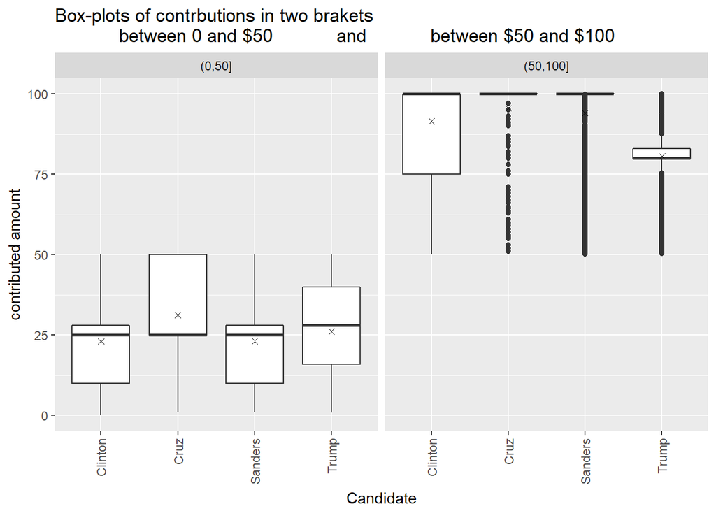

However, the (50,100] bracket is a very different story, all distributions are skewed to different degrees. Except for Trump, all candidate’s median is very close to $100. Trump’s is the least skewed, while the others are heavily skewed to the left.

In either brackets the distributions of all contributions is far from the normal distribution. I do not pursue statistical analysis of means within these brackets.

Lets look at contributions using box-plot for each party:

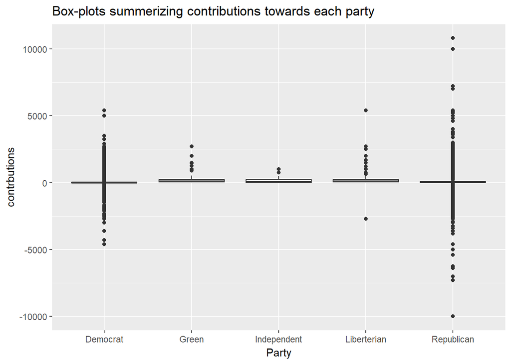

Most contributions are small across parties. Contributions to republican candidates are far wide spread. Parties other than Republicans and Democrats are have much less refund if any and the largest contributions are much smaller.

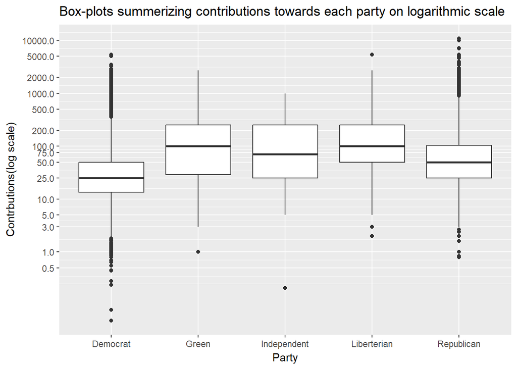

There is not clear whether there is much difference in mean between the parties.

Lets zoom in towards contributed amounts less than 1000 and 100 respectively:

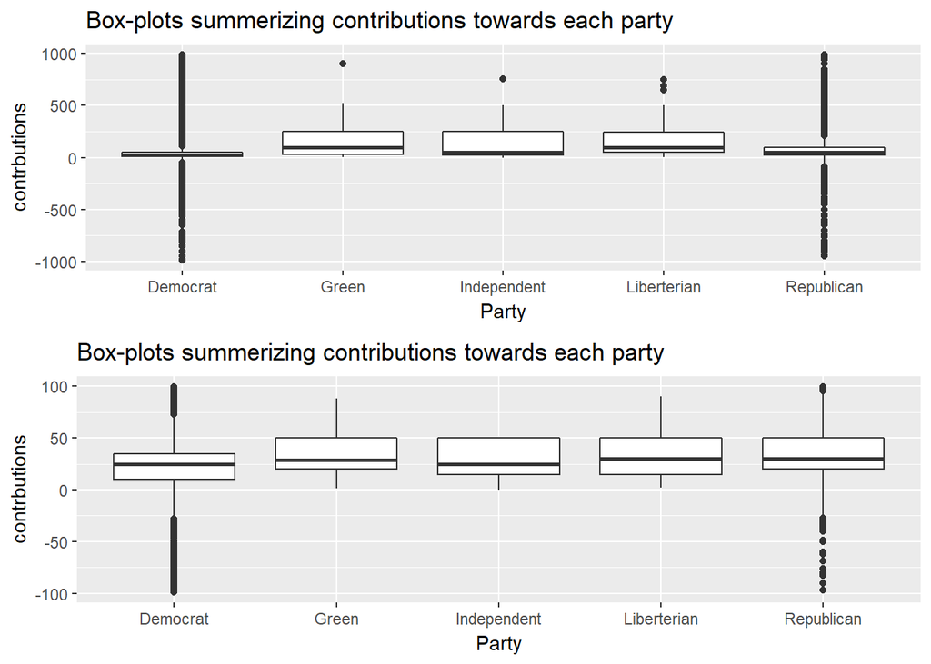

We test statistically for the difference in means of contributed amounts towards the parties using analysis of variance applied on logarithm transform of the contributions, since the transformed values are normally distributed.

```
##                 Df Sum Sq Mean Sq F value Pr(>F)
## cand_party       4   4257  1064.3    3238 <2e-16 ***
## Residuals   247427  81335     0.3
## ---
## Signif. codes:  0 '***' 0.001 '**' 0.01 '*' 0.05 '.' 0.1 ' ' 1
```

The results here show that means of the parties are statistically different. So now we apply Tukey’s procedure to determine which parties are statistically different on the mean.

```
##   Tukey multiple comparisons of means
##     95% family-wise confidence level
##     factor levels have been ordered
##
## Fit: aov(formula = log10(contb_amt) ~ cand_party, data = subset(contrib, contb_amt > 0))
##
## $cand_party
##                               diff         lwr       upr     p adj
## Republican-Democrat     0.32254657  0.31464181 0.3304513 0.0000000
## Independent-Democrat    0.37734528  0.10910643 0.6455841 0.0011753
## Green-Democrat          0.50556874  0.42787139 0.5832661 0.0000000
## Liberterian-Democrat    0.54421547  0.47007666 0.6183543 0.0000000
## Independent-Republican  0.05479871 -0.21351049 0.3231079 0.9810866
## Green-Republican        0.18302216  0.10508229 0.2609620 0.0000000
## Liberterian-Republican  0.22166889  0.14727596 0.2960618 0.0000000
## Green-Independent       0.12822345 -0.15099729 0.4074442 0.7202585
## Liberterian-Independent 0.16687018 -0.11138134 0.4451217 0.4742945
## Liberterian-Green       0.03864673 -0.06863189 0.1459253 0.8632151
```

Tukey’s procedure comparing the parties on mean of log transformed contributions shows that the Democratic party is statistically lower than the mean of any other party. The Libertarian and the green parties means are not significantly different. The Republican party is different from other parties except the Independent candidate.

Lets examine if there is any difference in contributions between people in cities, villages, town or other unrecognized places. First we look at a box plot with amount on logarithmic scale

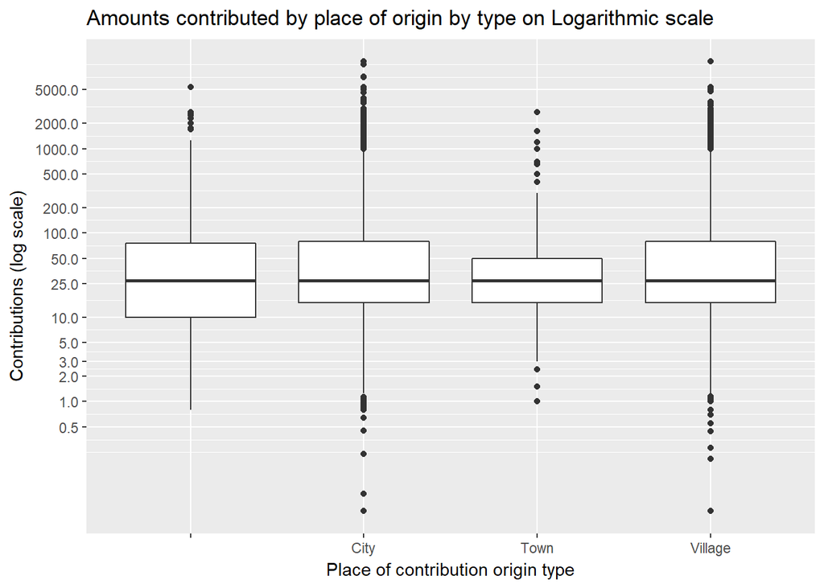

We see from the box plot above, that contributions from cities or villages are very similar in spread and median. Keep in mind the frequency plots above, that there are more contributions from city dwellers than from village dwellers.

Lets test for the difference of amounts contributed excluding refunds between the different places. Again I take logarithmic transform of the contributions since it satisfies the normality assumption.

```
##                 Df Sum Sq Mean Sq F value Pr(>F)
## type             3     50  16.777   48.53 <2e-16 ***
## Residuals   247428  85542   0.346
## ---
## Signif. codes:  0 '***' 0.001 '**' 0.01 '*' 0.05 '.' 0.1 ' ' 1
```

The analysis of variance show that there is difference between place types. Now we apply Tukey’s’ procedue to find out which are the different ones.

```
##   Tukey multiple comparisons of means
##     95% family-wise confidence level
##     factor levels have been ordered
##
## Fit: aov(formula = log10(contb_amt) ~ type, data = subset(contrib, contb_amt > 0))
##
## $type
##                     diff          lwr         upr     p adj
## Town-        0.029511709 -0.020225516 0.079248933 0.4228051
## Village-     0.105979611  0.080553259 0.131405963 0.0000000
## City-        0.109399343  0.084202838 0.134595847 0.0000000
## Village-Town 0.076467903  0.033110454 0.119825351 0.0000348
## City-Town    0.079887634  0.036664576 0.123110692 0.0000122
## City-Village 0.003419731 -0.002978761 0.009818224 0.5163255
```

Tukey’s procedure on log transformed contributions shows that the means between villages and cities are not statistically different, between towns and those collection of places outside the state and unincorporated places are also not different statistically. However, cities and villages means are different from towns as well are from the unincorporated places and other places outside the state.

#### Population versus contributions

To what degree does the population of the place had an effect on contributions from a given location ? we try to answer this question partially here. To do this we lump all contributions from each place. Lets look at a plot of total contributions per place versus the population of that place.

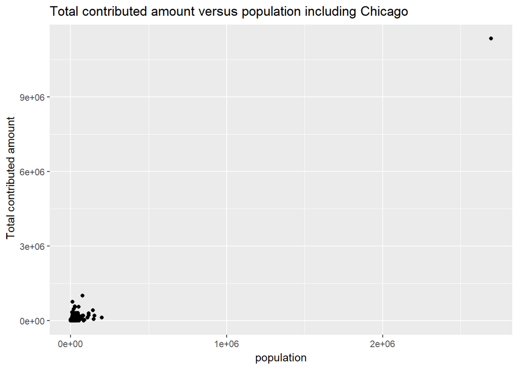

Chicago a city with population close to 2.7 million stand by it self. We need a plot for cities less than half a million or 200 thousand.

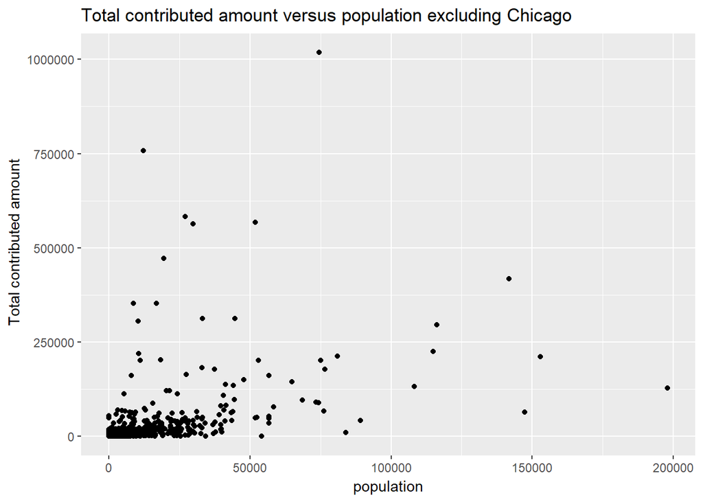

Some small population cities have much larger contributions compared to cities with comparable or higher population.

The size of the population and contributions suggest to consider transforming the data to log scale, and then try a linear fit.

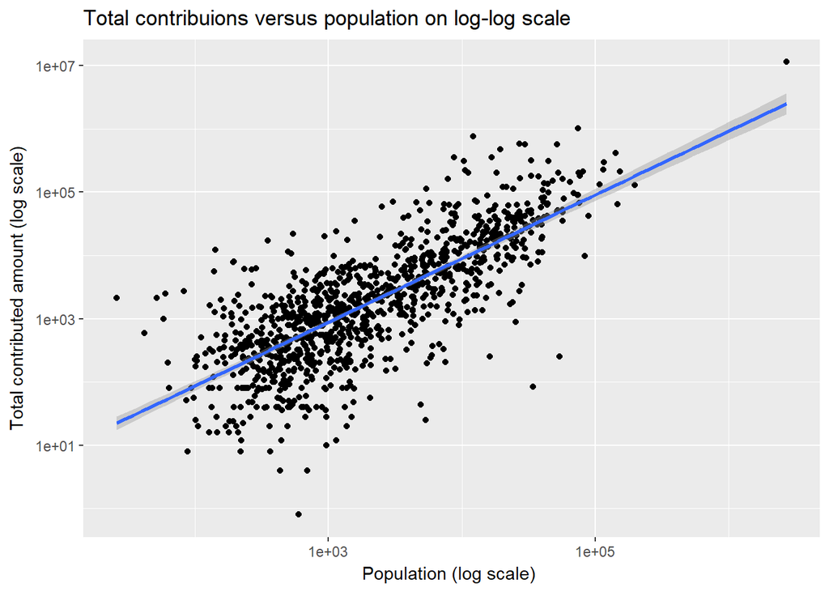

The scatter plot shows good correlation between population size and total contributed amount We also observe there is higher variability about the linear fit, for populations around 1000.

We attempt a least square linear fit to see any relation between total contribution and population. We expect the size of Chicago to be an influence point. We can reduce the influence by using logarithmic transformation on both variables.

```
##
## Call:
## lm(formula = log10(total_amt) ~ log10(population), data = subset(contb_by_city,
##     (population < 5e+06) & (population > 0)))
##
## Residuals:
##      Min       1Q   Median       3Q      Max
## -2.81829 -0.33377  0.03685  0.35195  1.99882
##
## Coefficients:
##                   Estimate Std. Error t value Pr(>|t|)
## (Intercept)       -0.07489    0.08843  -0.847    0.397
## log10(population)  1.00626    0.02607  38.597   <2e-16 ***
## ---
## Signif. codes:  0 '***' 0.001 '**' 0.01 '*' 0.05 '.' 0.1 ' ' 1
##
## Residual standard error: 0.6192 on 1065 degrees of freedom
## Multiple R-squared:  0.5831, Adjusted R-squared:  0.5827
## F-statistic:  1490 on 1 and 1065 DF,  p-value: < 2.2e-16
```

we see that there is a moderate associate between log base 10 of the total contributions per place and log base 10 of population.

Now we plot the mean amount against the population of a place.

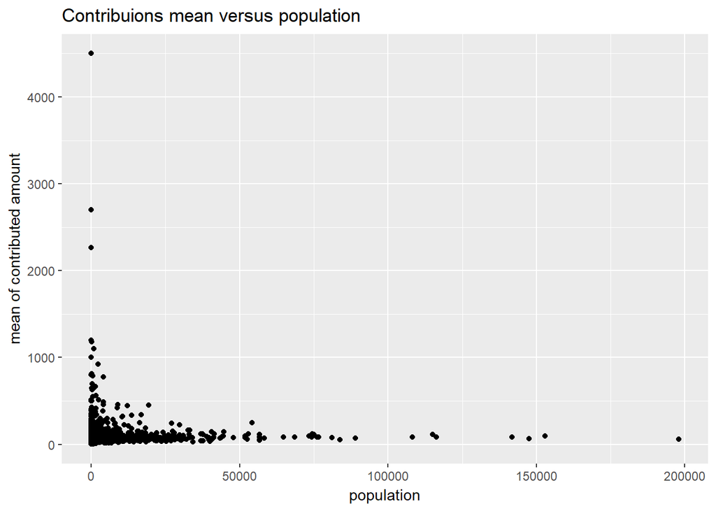

We observe that most contributions are small especially for populations over 50000. However, beware that, contributions that came from outside the state or unincorporated places show up here at population 0 or places that lie outside of the state. The mean amount is rather a total amount from these particular locations. That is there is only one person who made a large contribution from these locations.

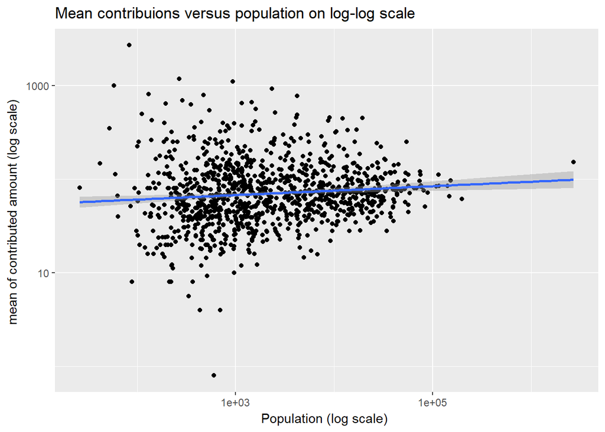

A scatter plot and a linear fit with a slope that is almost zero show low correlation between population and mean amount.

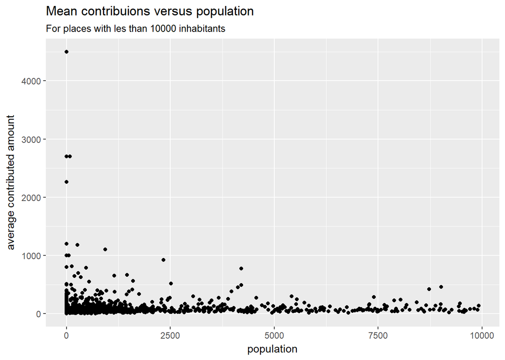